# Deliverable -1

## a. Univariate analysis

```python
import numpy as np
import pandas as pd
import matplotlib.pyplot as plt
import scipy.stats as stats
import seaborn as sns
from sklearn.model_selection  import train_test_split
```

```python
concrete_data = pd.read_csv('concrete.csv')
concrete_data.head()
```

|  | cement | slag | ash | water | superplastic | coarseagg | fineagg | age | strength |
| --- | --- | --- | --- | --- | --- | --- | --- | --- | --- |
| 0 | 141.3 | 212.0 | 0.0 | 203.5 | 0.0 | 971.8 | 748.5 | 28 | 29.89 |
| 1 | 168.9 | 42.2 | 124.3 | 158.3 | 10.8 | 1080.8 | 796.2 | 14 | 23.51 |
| 2 | 250.0 | 0.0 | 95.7 | 187.4 | 5.5 | 956.9 | 861.2 | 28 | 29.22 |
| 3 | 266.0 | 114.0 | 0.0 | 228.0 | 0.0 | 932.0 | 670.0 | 28 | 45.85 |
| 4 | 154.8 | 183.4 | 0.0 | 193.3 | 9.1 | 1047.4 | 696.7 | 28 | 18.29 |

```python
concrete_data.describe()
```

|  | cement | slag | ash | water | superplastic | coarseagg | fineagg | age | strength |
| --- | --- | --- | --- | --- | --- | --- | --- | --- | --- |
| count | 1030.000000 | 1030.000000 | 1030.000000 | 1030.000000 | 1030.000000 | 1030.000000 | 1030.000000 | 1030.000000 | 1030.000000 |
| mean | 281.167864 | 73.895825 | 54.188350 | 181.567282 | 6.204660 | 972.918932 | 773.580485 | 45.662136 | 35.817961 |
| std | 104.506364 | 86.279342 | 63.997004 | 21.354219 | 5.973841 | 77.753954 | 80.175980 | 63.169912 | 16.705742 |
| min | 102.000000 | 0.000000 | 0.000000 | 121.800000 | 0.000000 | 801.000000 | 594.000000 | 1.000000 | 2.330000 |
| 25% | 192.375000 | 0.000000 | 0.000000 | 164.900000 | 0.000000 | 932.000000 | 730.950000 | 7.000000 | 23.710000 |
| 50% | 272.900000 | 22.000000 | 0.000000 | 185.000000 | 6.400000 | 968.000000 | 779.500000 | 28.000000 | 34.445000 |
| 75% | 350.000000 | 142.950000 | 118.300000 | 192.000000 | 10.200000 | 1029.400000 | 824.000000 | 56.000000 | 46.135000 |
| max | 540.000000 | 359.400000 | 200.100000 | 247.000000 | 32.200000 | 1145.000000 | 992.600000 | 365.000000 | 82.600000 |

```python
concrete_data.shape
```

```
(1030, 9)
```

```python
concrete_data.info()
```

```
<class 'pandas.core.frame.DataFrame'>
RangeIndex: 1030 entries, 0 to 1029
Data columns (total 9 columns):
cement          1030 non-null float64
slag            1030 non-null float64
ash             1030 non-null float64
water           1030 non-null float64
superplastic    1030 non-null float64
coarseagg       1030 non-null float64
fineagg         1030 non-null float64
age             1030 non-null int64
strength        1030 non-null float64
dtypes: float64(8), int64(1)
memory usage: 72.5 KB
```

```python
# number of missing values (only the ones recognised as missing values) in each of the attributes
pd.DataFrame( concrete_data.isnull().sum(), columns= ['Number of missing values'])
```

|  | Number of missing values |
| --- | --- |
| cement | 0 |
| slag | 0 |
| ash | 0 |
| water | 0 |
| superplastic | 0 |
| coarseagg | 0 |
| fineagg | 0 |
| age | 0 |
| strength | 0 |

```python
concrete_data.describe() # the output results provide the five number summary of the data.
```

|  | cement | slag | ash | water | superplastic | coarseagg | fineagg | age | strength |
| --- | --- | --- | --- | --- | --- | --- | --- | --- | --- |
| count | 1030.000000 | 1030.000000 | 1030.000000 | 1030.000000 | 1030.000000 | 1030.000000 | 1030.000000 | 1030.000000 | 1030.000000 |
| mean | 281.167864 | 73.895825 | 54.188350 | 181.567282 | 6.204660 | 972.918932 | 773.580485 | 45.662136 | 35.817961 |
| std | 104.506364 | 86.279342 | 63.997004 | 21.354219 | 5.973841 | 77.753954 | 80.175980 | 63.169912 | 16.705742 |
| min | 102.000000 | 0.000000 | 0.000000 | 121.800000 | 0.000000 | 801.000000 | 594.000000 | 1.000000 | 2.330000 |
| 25% | 192.375000 | 0.000000 | 0.000000 | 164.900000 | 0.000000 | 932.000000 | 730.950000 | 7.000000 | 23.710000 |
| 50% | 272.900000 | 22.000000 | 0.000000 | 185.000000 | 6.400000 | 968.000000 | 779.500000 | 28.000000 | 34.445000 |
| 75% | 350.000000 | 142.950000 | 118.300000 | 192.000000 | 10.200000 | 1029.400000 | 824.000000 | 56.000000 | 46.135000 |
| max | 540.000000 | 359.400000 | 200.100000 | 247.000000 | 32.200000 | 1145.000000 | 992.600000 | 365.000000 | 82.600000 |

```
Mean:  281.1678640776698
Median:  272.9
Mode:  362.6
```

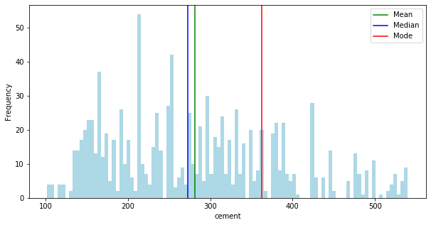

```python
mean=concrete_data['cement'].mean()
median=concrete_data['cement'].median()
mode=concrete_data['cement'].mode()

print('Mean: ',mean,'\nMedian: ',median,'\nMode: ',mode[0])

plt.figure(figsize=(10,5)) # set the figure size
plt.hist(concrete_data['cement'],bins=100,color='lightblue') #Plot the histogram

plt.axvline(mean,color='green',label='Mean')
plt.axvline(median,color='blue',label='Median')
plt.axvline(mode[0],color='red',label='Mode')

plt.xlabel('cement')         # label the x-axis
plt.ylabel('Frequency')   # label the y-axis
plt.legend()              # Plot the legend
plt.show()
```

- The distribution of 'cement' is normal distribution

```
Mean:  73.89582524271844
Median:  22.0
Mode:  0.0
```

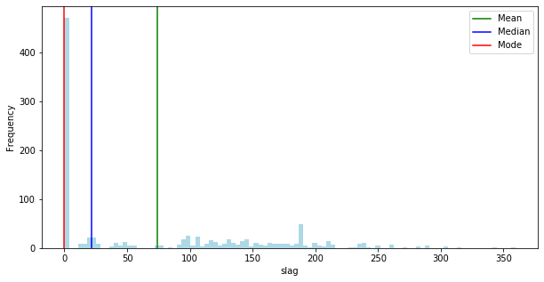

```python
mean=concrete_data['slag'].mean()
median=concrete_data['slag'].median()
mode=concrete_data['slag'].mode()

print('Mean: ',mean,'\nMedian: ',median,'\nMode: ',mode[0])

plt.figure(figsize=(10,5)) # set the figure size
plt.hist(concrete_data['slag'],bins=100,color='lightblue') #Plot the histogram

plt.axvline(mean,color='green',label='Mean')
plt.axvline(median,color='blue',label='Median')
plt.axvline(mode[0],color='red',label='Mode')

plt.xlabel('slag')         # label the x-axis
plt.ylabel('Frequency')   # label the y-axis
plt.legend()              # Plot the legend
plt.show()
```

- Right Skewed distribution for 'Slag' variable

```
Mean:  54.188349514563086
Median:  0.0
Mode:  0.0
```

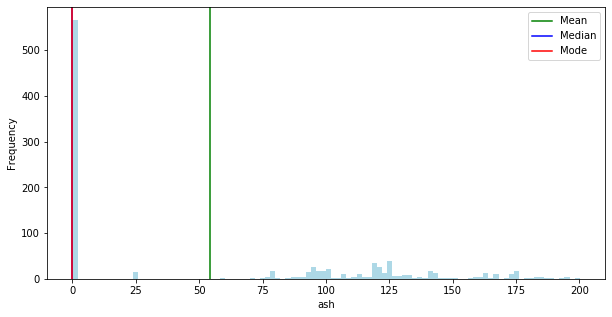

```python
mean=concrete_data['ash'].mean()
median=concrete_data['ash'].median()
mode=concrete_data['ash'].mode()

print('Mean: ',mean,'\nMedian: ',median,'\nMode: ',mode[0])

plt.figure(figsize=(10,5)) # set the figure size
plt.hist(concrete_data['ash'],bins=100,color='lightblue') #Plot the histogram

plt.axvline(mean,color='green',label='Mean')
plt.axvline(median,color='blue',label='Median')
plt.axvline(mode[0],color='red',label='Mode')

plt.xlabel('ash')         # label the x-axis
plt.ylabel('Frequency')   # label the y-axis
plt.legend()              # Plot the legend
plt.show()
```

- The distribution for 'ash' is right skewed

```
Mean:  181.56728155339798
Median:  185.0
Mode:  192.0
```

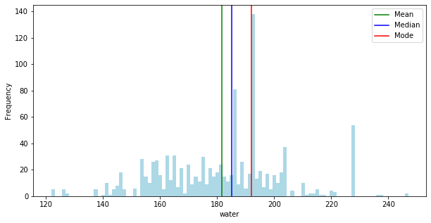

```python
mean=concrete_data['water'].mean()
median=concrete_data['water'].median()
mode=concrete_data['water'].mode()

print('Mean: ',mean,'\nMedian: ',median,'\nMode: ',mode[0])

plt.figure(figsize=(10,5)) # set the figure size
plt.hist(concrete_data['water'],bins=100,color='lightblue') #Plot the histogram

plt.axvline(mean,color='green',label='Mean')
plt.axvline(median,color='blue',label='Median')
plt.axvline(mode[0],color='red',label='Mode')

plt.xlabel('water')         # label the x-axis
plt.ylabel('Frequency')   # label the y-axis
plt.legend()              # Plot the legend
plt.show()
```

- The distribution for 'water' is normal distribution

```
Mean:  6.204660194174756
Median:  6.4
Mode:  0.0
```

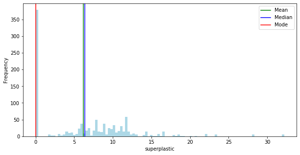

```python
mean=concrete_data['superplastic'].mean()
median=concrete_data['superplastic'].median()
mode=concrete_data['superplastic'].mode()

print('Mean: ',mean,'\nMedian: ',median,'\nMode: ',mode[0])

plt.figure(figsize=(10,5)) # set the figure size
plt.hist(concrete_data['superplastic'],bins=100,color='lightblue') #Plot the histogram

plt.axvline(mean,color='green',label='Mean')
plt.axvline(median,color='blue',label='Median')
plt.axvline(mode[0],color='red',label='Mode')

plt.xlabel('superplastic')         # label the x-axis
plt.ylabel('Frequency')   # label the y-axis
plt.legend()              # Plot the legend
plt.show()
```

- The distribution for 'superplastic' is right skewed

```
Mean:  972.918932038835
Median:  968.0
Mode:  932.0
```

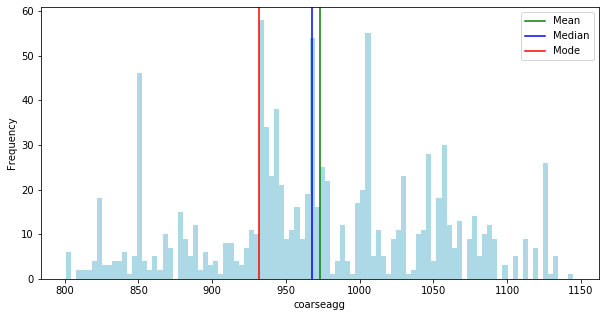

```python
mean=concrete_data['coarseagg'].mean()
median=concrete_data['coarseagg'].median()
mode=concrete_data['coarseagg'].mode()

print('Mean: ',mean,'\nMedian: ',median,'\nMode: ',mode[0])

plt.figure(figsize=(10,5)) # set the figure size
plt.hist(concrete_data['coarseagg'],bins=100,color='lightblue') #Plot the histogram

plt.axvline(mean,color='green',label='Mean')
plt.axvline(median,color='blue',label='Median')
plt.axvline(mode[0],color='red',label='Mode')

plt.xlabel('coarseagg')         # label the x-axis
plt.ylabel('Frequency')   # label the y-axis
plt.legend()              # Plot the legend
plt.show()
```

- the distribution for 'coarseagg' is normal

```
Mean:  773.5804854368932
Median:  779.5
Mode:  594.0
```

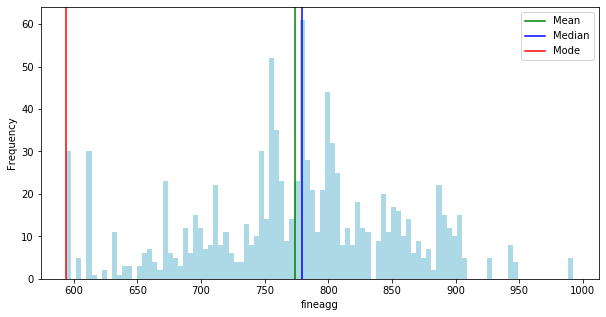

```python
mean=concrete_data['fineagg'].mean()
median=concrete_data['fineagg'].median()
mode=concrete_data['fineagg'].mode()

print('Mean: ',mean,'\nMedian: ',median,'\nMode: ',mode[0])

plt.figure(figsize=(10,5)) # set the figure size
plt.hist(concrete_data['fineagg'],bins=100,color='lightblue') #Plot the histogram

plt.axvline(mean,color='green',label='Mean')
plt.axvline(median,color='blue',label='Median')
plt.axvline(mode[0],color='red',label='Mode')

plt.xlabel('fineagg')         # label the x-axis
plt.ylabel('Frequency')   # label the y-axis
plt.legend()              # Plot the legend
plt.show()
```

- The distribution for 'fineagg' is normal

```
Mean:  45.662135922330094
Median:  28.0
Mode:  28
```

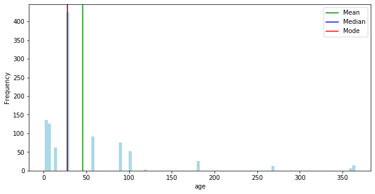

```python
mean=concrete_data['age'].mean()
median=concrete_data['age'].median()
mode=concrete_data['age'].mode()

print('Mean: ',mean,'\nMedian: ',median,'\nMode: ',mode[0])

plt.figure(figsize=(10,5)) # set the figure size
plt.hist(concrete_data['age'],bins=100,color='lightblue') #Plot the histogram

plt.axvline(mean,color='green',label='Mean')
plt.axvline(median,color='blue',label='Median')
plt.axvline(mode[0],color='red',label='Mode')

plt.xlabel('age')         # label the x-axis
plt.ylabel('Frequency')   # label the y-axis
plt.legend()              # Plot the legend
plt.show()
```

- The distribution for 'age' is right skewed

```
Mean:  35.81796116504854
Median:  34.445
Mode:  33.4
```

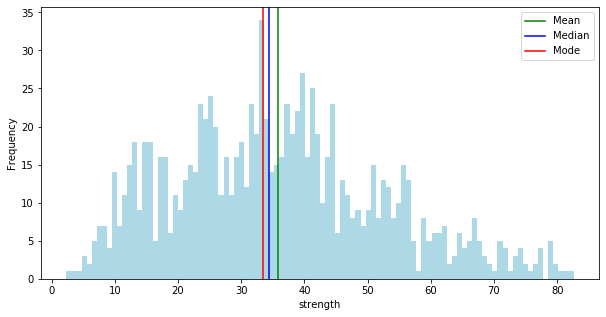

```python
mean=concrete_data['strength'].mean()
median=concrete_data['strength'].median()
mode=concrete_data['strength'].mode()

print('Mean: ',mean,'\nMedian: ',median,'\nMode: ',mode[0])

plt.figure(figsize=(10,5)) # set the figure size
plt.hist(concrete_data['strength'],bins=100,color='lightblue') #Plot the histogram

plt.axvline(mean,color='green',label='Mean')
plt.axvline(median,color='blue',label='Median')
plt.axvline(mode[0],color='red',label='Mode')

plt.xlabel('strength')         # label the x-axis
plt.ylabel('Frequency')   # label the y-axis
plt.legend()              # Plot the legend
plt.show()
```

- The distribution for 'strength' is normal

### Visualize Outliers using Box plot

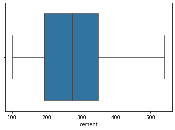

```python
sns.boxplot(x=concrete_data['cement'])   # box plot
```

- There dont seem to have outliers for the variable 'cement'

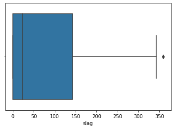

```python
sns.boxplot(x=concrete_data['slag']) # box plot
```

- There is one data points after 350 that is listed as an outlier

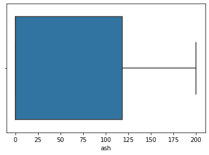

```python
sns.boxplot(x=concrete_data['ash'])
```

- There is no outlier for the variable 'ash'

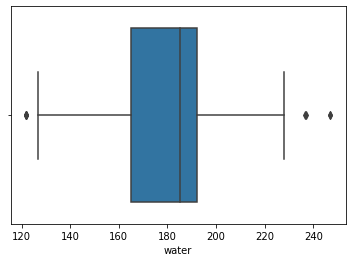

```python
sns.boxplot(x=concrete_data['water'])
```

- There are outliers that lie outside the range 13 to 230 for the variable 'water'

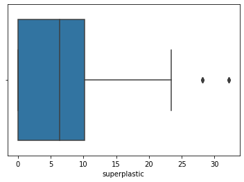

```python
sns.boxplot(x=concrete_data['superplastic'])
```

- There are outliers above 25 for the variable 'superplastic'

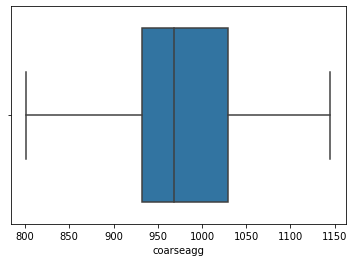

```python
sns.boxplot(x=concrete_data['coarseagg'])
```

- There is no outlier for the variable 'coarseagg'

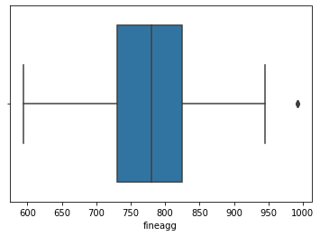

```python
sns.boxplot(x=concrete_data['fineagg'])
```

- The is an outliers after the data point 950 for the variable 'fineagg'

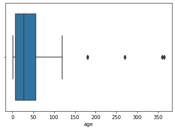

```python
sns.boxplot(x=concrete_data['age'])
```

- There are several outlier beyond 125 for the variable 'age'

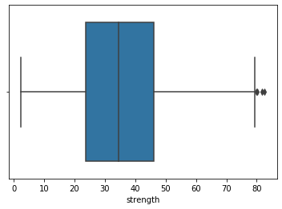

```python
sns.boxplot(x=concrete_data['strength'])
```

- There are outliers beyond 77 for the variable 'strength'

## b. Multivariate analysis

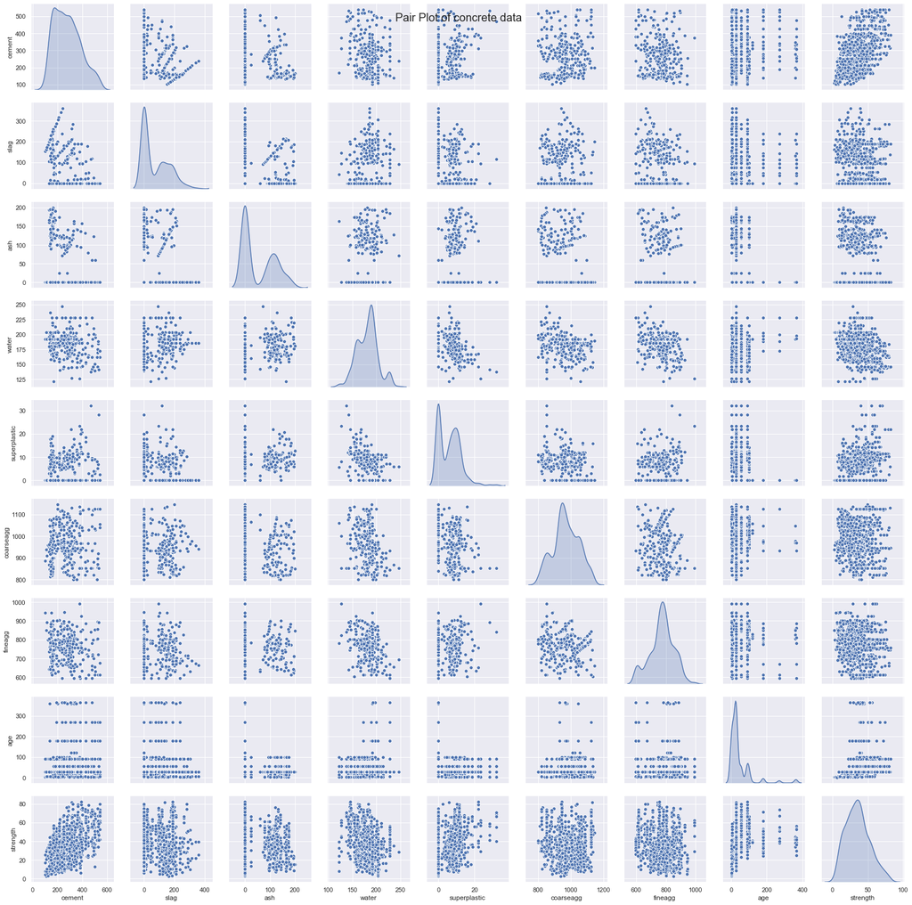

```python
sns.pairplot(concrete_data, diag_kind='kde')
plt.suptitle('Pair Plot of concrete data',
             size = 20);# plots scatter plots for every pair of attributes and histograms along the diagonal
plt.show()
```

## c. Pick one strategy to address the presence outliers and missing values and perform necessary imputation

```python
concrete_data = concrete_data.replace('?', np.nan)
```

```python
#instead of dropping the rows, lets replace the missing values with median value.
concrete_data.median()
```

```
cement          272.900
slag             22.000
ash               0.000
water           185.000
superplastic      6.400
coarseagg       968.000
fineagg         779.500
age              28.000
strength         34.445
dtype: float64
```

```python
# replace the missing values with median value.
# Note, we do not need to specify the column names below
# every column's missing value is replaced with that column's median respectively  (axis =0 means columnwise)

medianFiller = lambda x: x.fillna(x.median())
concrete_data = concrete_data.apply(medianFiller,axis=0)
```

```python
concrete_data.head(10)
```

|  | cement | slag | ash | water | superplastic | coarseagg | fineagg | age | strength |
| --- | --- | --- | --- | --- | --- | --- | --- | --- | --- |
| 0 | 141.3 | 212.0 | 0.0 | 203.5 | 0.0 | 971.8 | 748.5 | 28 | 29.89 |
| 1 | 168.9 | 42.2 | 124.3 | 158.3 | 10.8 | 1080.8 | 796.2 | 14 | 23.51 |
| 2 | 250.0 | 0.0 | 95.7 | 187.4 | 5.5 | 956.9 | 861.2 | 28 | 29.22 |
| 3 | 266.0 | 114.0 | 0.0 | 228.0 | 0.0 | 932.0 | 670.0 | 28 | 45.85 |
| 4 | 154.8 | 183.4 | 0.0 | 193.3 | 9.1 | 1047.4 | 696.7 | 28 | 18.29 |
| 5 | 255.0 | 0.0 | 0.0 | 192.0 | 0.0 | 889.8 | 945.0 | 90 | 21.86 |
| 6 | 166.8 | 250.2 | 0.0 | 203.5 | 0.0 | 975.6 | 692.6 | 7 | 15.75 |
| 7 | 251.4 | 0.0 | 118.3 | 188.5 | 6.4 | 1028.4 | 757.7 | 56 | 36.64 |
| 8 | 296.0 | 0.0 | 0.0 | 192.0 | 0.0 | 1085.0 | 765.0 | 28 | 21.65 |
| 9 | 155.0 | 184.0 | 143.0 | 194.0 | 9.0 | 880.0 | 699.0 | 28 | 28.99 |